# Análisis Espectral No Paramétrico

## Objetivos

## Objetivo General

Profundizar en la teoría del análisis espectral no paramétrico así como sus aplicaciones en series de tiempo.

## Objetivos específicos

- Repasar los conceptos esenciales de la teoría del análisis espectral como análisis de Fourier, el periodograma, la densidad espectral y otros.
- Investigar para qué tipo de series de tiempo el análisis espectral es una herramienta fundamental.
- Utilizar el programa estadístico R para filtrar la serie de las temperaturas máximas de Liberia, utilizado la teoría de análisis espectral.

## Marco Teórico

## _

Cualquier proceso estacionario se puede representar mediante una combinación lineal de senos y cosenos se puede expresar aproximadamente de la siguiente forma:

\(X_t = \sum_{j = 1}^{q}[U_{j1} \cos(2\pi \omega_{j} t) + U_{j2} \sin(2\pi\omega_{j} t)\)

Donde \(U_{k1}\), \(U_{k2}\) para \(k = 1,2,...,q\) son variable aleatorias con media cero y varianza \(\sigma_{k}^{2}\) y \(\omega_{j} = \frac{j}{n}\) son los ciclos.

## Análisis espectral no paramétrico

## Datos

Serie: Temperaturas máximas diarias reportadas en Liberia entre el 2011 y 2014. *National Oceanic and Atmospheric Administration*

[interactive chart not shown]

## Estimación espectral no paramétrica

## El Peridiograma

- Estimador espectral
- Descrubrir los componentes periódicos de la serie

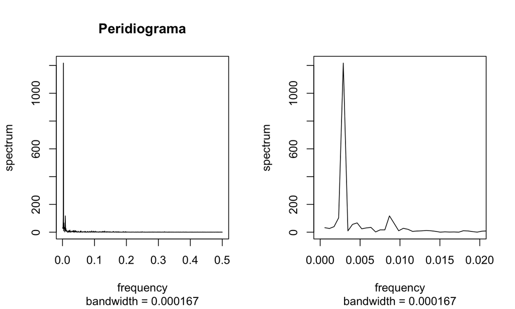

## Suavizado del peridiograma

| Freq | Lower | Upper | Power |
| --- | --- | --- | --- |
| 0.00289 | 306.87359 | 85694.906 | 1217.33807 |
| 0.00868 | 29.61797 | 8270.861 | 117.49162 |
| 0.00231 | 26.12525 | 7295.516 | 103.63637 |
| 0.00463 | 16.84151 | 4703.018 | 66.80867 |
| 0.00926 | 16.18619 | 4520.017 | 64.20905 |

## Suavizado del peridiograma

- Filtrado Lineal
- Permite delimitar la varianza en determinados intervalos de frecuencia

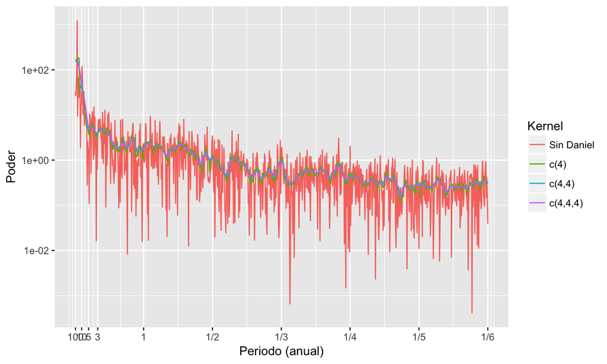

## Tappering

## Extracción de la señal

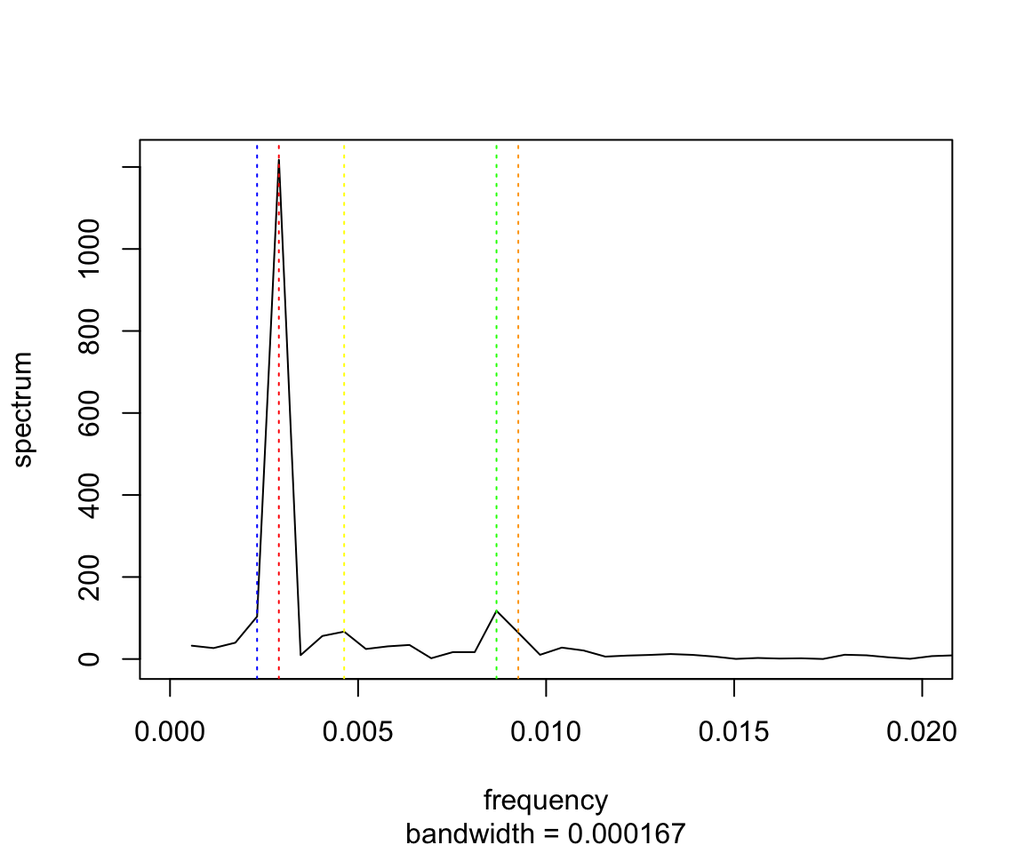

## Extracción de la señal

| Frecuencia | Periodo | Poder |
| --- | --- | --- |
| 0.00289 | 345.6 | 1217.33807 |
| 0.00868 | 115.2 | 117.49162 |
| 0.00231 | 432.0 | 103.63637 |
| 0.00463 | 216.0 | 66.80867 |
| 0.00926 | 108.0 | 64.20905 |

## Extracción de la señal

[interactive chart not shown]

## Extracción de la señal

[interactive chart not shown]